# Coursera Machine Learning Project

Shawne A Pierson

January 9, 2018

## Background

Using devices such as Jawbone Up, Nike FuelBand, and Fitbit it is now possible to collect a large amount of data about personal activity relatively inexpensively. These type of devices are part of the quantified self movement - a group of enthusiasts who take measurements about themselves regularly to improve their health, to find patterns in their behavior, or because they are tech geeks. One thing that people regularly do is quantify how much of a particular activity they do, but they rarely quantify how well they do it. In this project, your goal will be to use data from accelerometers on the belt, forearm, arm, and dumbell of 6 participants. They were asked to perform barbell lifts correctly and incorrectly in 5 different ways. More information is available from the website here: http://web.archive.org/web/20161224072740/http:/groupware.les.inf.puc-rio.br/har (see the section on the Weight Lifting Exercise Dataset).

## Data Loading and Exploratory Analysis

```r
# load libraries to generate required graphs and analysis
library(knitr)
library(caret);
library(rattle);
library(rpart);
library(rpart.plot)
library(randomForest);
library(repmis)
library(gbm)
# Set my seed value to allow reproducibility
set.seed(979)

# Set my working directory
setwd("~/Coursera/Practical Machine Learning/Course Project/Coursera-Practical-Machine-Learning-Course-Prj")

# Read the csv data files
training <- read.csv("data/pml-training.csv")
testing <- read.csv("data/pml-testing.csv")

# Partition my training and test datasets
inTrain  <- createDataPartition(training$classe, p=0.7, list=FALSE)
Train_Data <- training[inTrain, ]
Test_Data  <- training[-inTrain, ]
```

## Perform some initial analysis on the Data

```r
dim(Train_Data)
```

```
## [1] 13737   160
```

```r
dim(Test_Data)
```

```
## [1] 5885  160
```

The Training data has 13,737 rows and 160 columns of data.  
The Test data has 5,885 rows and 160 columns of data.

## Clean the data

```r
My_Non_Zero_Values <- nearZeroVar(Train_Data)
Train_Data <- Train_Data[, -My_Non_Zero_Values]
Test_Data  <- Test_Data[, -My_Non_Zero_Values]
```

## Perform post-Non_Zero_Values analysis on the Data

```r
dim(Train_Data)
```

```
## [1] 13737   103
```

```r
dim(Test_Data)
```

```
## [1] 5885  103
```

The Training data has 13,737 rows and 103 columns of data.  
The Test data has 5,885 rows and 103 columns of data.

```r
dim(Train_Data)
```

```
## [1] 13737    59
```

```r
dim(Test_Data)
```

```
## [1] 5885   59
```

The Training data has 13,737 rows and 59 columns of data.  
The Test data has 5,885 rows and 59 columns of data.

From this analysis, we can determine that the first six variables have little predicting power in my mind for the outcome we are seeking. Let’s tidy these data further.

```r
Train_Data <- Train_Data[, -c(1:6)]
Test_Data <- Test_Data[, -c(1:6)]
```

## Perform post-predicting power tidy up analysis on the Data

```r
dim(Train_Data)
```

```
## [1] 13737    53
```

```r
dim(Test_Data)
```

```
## [1] 5885   53
```

The Training data has 13,737 rows and 53 columns of data.  
The Test data has 5,885 rows and 53 columns of data.

## Prediction Models

From the Machine Learning course, I will perform three prediction models (Decision Tree, Generalized Boosted Model, and Random Forest). Based upon the highest level of accurary, I will select the best fit model and utilize the results of the model for my quiz prediction answers.

### Decision Tree

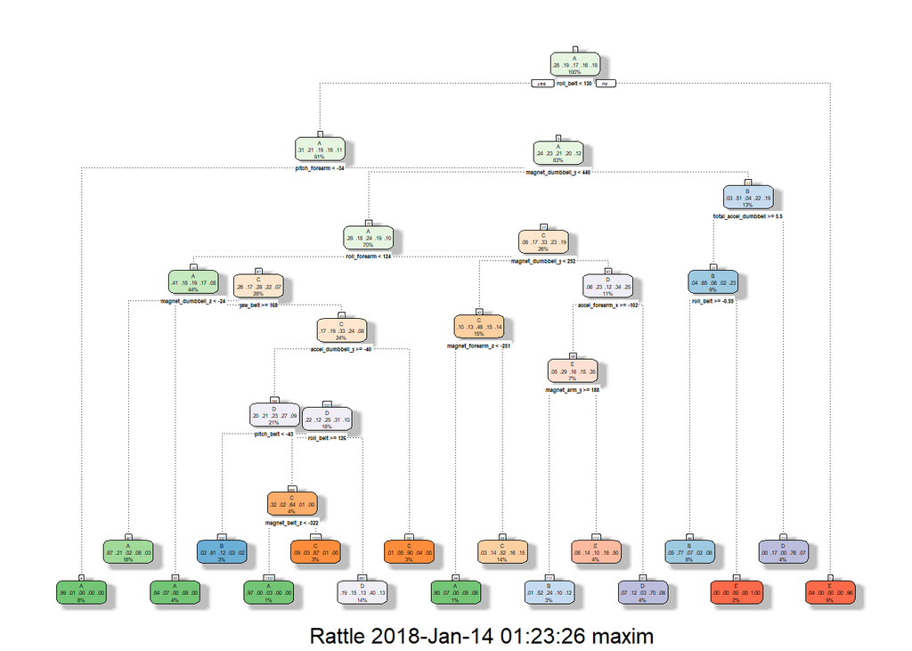

```r
set.seed(979)
My_Decision_Tree <- rpart(classe ~ ., data=Train_Data, method="class")
fancyRpartPlot(My_Decision_Tree)
```

```r
# Prediction against my Test_Data
My_Predict_Tree <- predict(My_Decision_Tree, newdata=Test_Data, type="class")
My_Confusion_Matrix <- confusionMatrix(My_Predict_Tree, Test_Data$classe)
My_Confusion_Matrix
```

```
## Confusion Matrix and Statistics
##
##           Reference
## Prediction    A    B    C    D    E
##          A 1367  219   27   86   36
##          B   33  557   70   31   62
##          C   48  134  792  143  121
##          D  183  191  110  663  176
##          E   43   38   27   41  687
##
## Overall Statistics
##
##                Accuracy : 0.6909
##                  95% CI : (0.6789, 0.7027)
##     No Information Rate : 0.2845
##     P-Value [Acc > NIR] : < 2.2e-16
##
##                   Kappa : 0.6096
##  Mcnemar's Test P-Value : < 2.2e-16
##
## Statistics by Class:
##
##                      Class: A Class: B Class: C Class: D Class: E
## Sensitivity            0.8166  0.48903   0.7719   0.6878   0.6349
## Specificity            0.9126  0.95870   0.9082   0.8659   0.9690
## Pos Pred Value         0.7879  0.73971   0.6397   0.5011   0.8218
## Neg Pred Value         0.9260  0.88659   0.9496   0.9340   0.9218
## Prevalence             0.2845  0.19354   0.1743   0.1638   0.1839
## Detection Rate         0.2323  0.09465   0.1346   0.1127   0.1167
## Detection Prevalence   0.2948  0.12795   0.2104   0.2248   0.1421
## Balanced Accuracy      0.8646  0.72386   0.8401   0.7768   0.8020
```

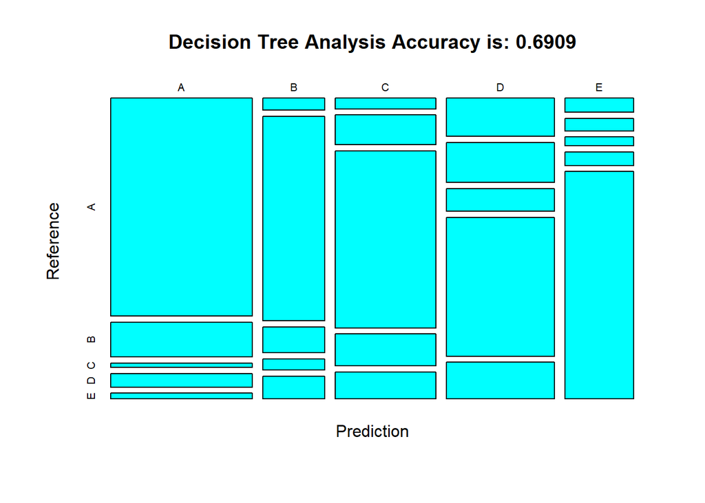

```r
# Generate a plot to determine visual results

My_Confusion_Matrix_Acc <- round(My_Confusion_Matrix$overall['Accuracy'], 4)
My_Title <- paste("Decision Tree Analysis Accuracy is:", My_Confusion_Matrix_Acc)

plot(My_Confusion_Matrix$table, col = c('cyan'), main = My_Title)
```

### Generalized Boosted Model (GBM)

```r
set.seed(979)
My_Ctrl_GBM <- trainControl(method = "repeatedcv", number = 5, repeats = 1)
My_Fit_GBM  <- train(classe ~ ., data=Train_Data, method = "gbm",
                    trControl = My_Ctrl_GBM, verbose = FALSE)
My_Fit_GBM$finalModel
```

```
## A gradient boosted model with multinomial loss function.
## 150 iterations were performed.
## There were 52 predictors of which 44 had non-zero influence.
```

```r
# Test dataset prediction
My_GBM_Predict <- predict(My_Fit_GBM, newdata=Test_Data)
My_Confusion_Matrix_GBM <- confusionMatrix(My_GBM_Predict, Test_Data$classe)
My_Confusion_Matrix_GBM
```

```
## Confusion Matrix and Statistics
##
##           Reference
## Prediction    A    B    C    D    E
##          A 1646   27    0    1    4
##          B   22 1089   33    7   10
##          C    5   22  981   38   15
##          D    1    0    9  914   11
##          E    0    1    3    4 1042
##
## Overall Statistics
##
##                Accuracy : 0.9638
##                  95% CI : (0.9587, 0.9684)
##     No Information Rate : 0.2845
##     P-Value [Acc > NIR] : < 2.2e-16
##
##                   Kappa : 0.9542
##  Mcnemar's Test P-Value : 2.855e-08
##
## Statistics by Class:
##
##                      Class: A Class: B Class: C Class: D Class: E
## Sensitivity            0.9833   0.9561   0.9561   0.9481   0.9630
## Specificity            0.9924   0.9848   0.9835   0.9957   0.9983
## Pos Pred Value         0.9809   0.9380   0.9246   0.9775   0.9924
## Neg Pred Value         0.9933   0.9894   0.9907   0.9899   0.9917
## Prevalence             0.2845   0.1935   0.1743   0.1638   0.1839
## Detection Rate         0.2797   0.1850   0.1667   0.1553   0.1771
## Detection Prevalence   0.2851   0.1973   0.1803   0.1589   0.1784
## Balanced Accuracy      0.9878   0.9705   0.9698   0.9719   0.9807
```

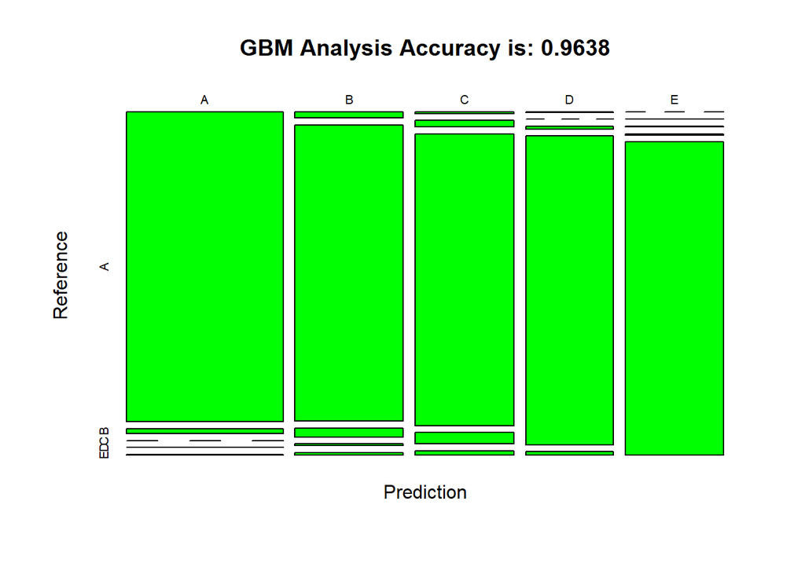

```r
# Generate a plot to determine visual results

My_Confusion_Matrix_GBM_Acc <- round(My_Confusion_Matrix_GBM$overall['Accuracy'], 4)
My_Title <- paste("GBM Analysis Accuracy is:", My_Confusion_Matrix_GBM_Acc)

plot(My_Confusion_Matrix_GBM$table, col = c('green'), main = My_Title)
```

### Random Forest

```r
set.seed(979)
My_Ctrl_RF <- trainControl(method="cv", number=3, verboseIter=FALSE)
My_Fit_RF <- train(classe ~ ., data=Train_Data, method="rf", trControl=My_Ctrl_RF)
My_Fit_RF$finalModel
```

```
##
## Call:
##  randomForest(x = x, y = y, mtry = param$mtry)
##                Type of random forest: classification
##                      Number of trees: 500
## No. of variables tried at each split: 27
##
##         OOB estimate of  error rate: 0.71%
## Confusion matrix:
##      A    B    C    D    E class.error
## A 3899    5    1    0    1 0.001792115
## B   21 2629    8    0    0 0.010910459
## C    0   13 2378    5    0 0.007512521
## D    0    0   28 2222    2 0.013321492
## E    0    2    6    5 2512 0.005148515
```

```r
# Execute a prediction against my Test data
MY_RF_Predict <- predict(My_Fit_RF, newdata=Test_Data)
My_Confusion_Matrix_RF <- confusionMatrix(MY_RF_Predict, Test_Data$classe)
My_Confusion_Matrix_RF
```

```
## Confusion Matrix and Statistics
##
##           Reference
## Prediction    A    B    C    D    E
##          A 1673    4    0    0    0
##          B    1 1132    3    0    1
##          C    0    3 1018   14    2
##          D    0    0    5  950    3
##          E    0    0    0    0 1076
##
## Overall Statistics
##
##                Accuracy : 0.9939
##                  95% CI : (0.9915, 0.9957)
##     No Information Rate : 0.2845
##     P-Value [Acc > NIR] : < 2.2e-16
##
##                   Kappa : 0.9923
##  Mcnemar's Test P-Value : NA
##
## Statistics by Class:
##
##                      Class: A Class: B Class: C Class: D Class: E
## Sensitivity            0.9994   0.9939   0.9922   0.9855   0.9945
## Specificity            0.9991   0.9989   0.9961   0.9984   1.0000
## Pos Pred Value         0.9976   0.9956   0.9817   0.9916   1.0000
## Neg Pred Value         0.9998   0.9985   0.9983   0.9972   0.9988
## Prevalence             0.2845   0.1935   0.1743   0.1638   0.1839
## Detection Rate         0.2843   0.1924   0.1730   0.1614   0.1828
## Detection Prevalence   0.2850   0.1932   0.1762   0.1628   0.1828
## Balanced Accuracy      0.9992   0.9964   0.9941   0.9919   0.9972
```

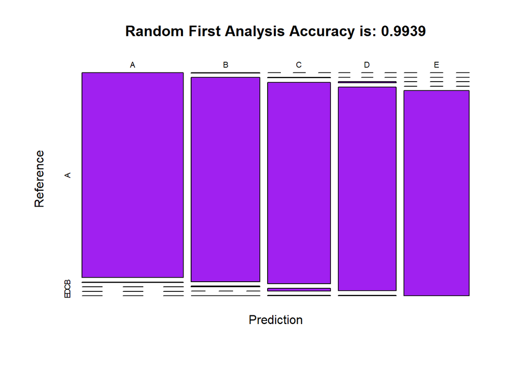

```r
# Generate a plot to determine visual results

My_Confusion_Matrix_RF_Acc <- round(My_Confusion_Matrix_RF$overall['Accuracy'], 4)
My_Title <- paste("Random First Analysis Accuracy is:", My_Confusion_Matrix_RF_Acc)

plot(My_Confusion_Matrix_RF$table, col = c('purple'), main = My_Title)
```

## Model Analysis Overview

In conclusion, the accuracy of my three regression modeling methods are:

- Decision Tree : 0.6909
- GBM : 0.9638
- Random Forest : 0.9939

Therefore, I will execute the Random Forest model in order to predict the 20 quiz results using the test data.

```r
MY_Prediction <- predict(My_Fit_RF, newdata = testing)
MY_Prediction
```

```
##  [1] B A B A A E D B A A B C B A E E A B B B
## Levels: A B C D E
```